# replicate_regression

## File naming scheme

Folders each contain DMS-MaP experimental data from a single transfection. Folders containing biological replicate data have the suffix "_Rep2" appended. Folders containing a single amplicon for cells that are also expressing the tethering protein (TP) have the suffix "-TP-amp#" where "amp#" refers to the amplicon that contains the tethering hairpin.

## Target mRNAs

- MCS = no-TH target mRNA
- 3UTR = Target mRNA with TH in 3'-UTR
- 5UTR = Target mRNA with TH in 5'-UTR
- CDS1 = Target mRNA with TH in CDS1 position
- CDS3 (or CDS2) = Target mRNA with TH in CDS2 position

Target mRNAs with TP expression

- 3UTR_TP = Target mRNA with TH in 3'-UTR and TP expression
- CDS1_TP = Target mRNA with TH in CDS1 and TP expression

## Explination of files

- -fasta
  - sequence of the target mRNA
- -Sample_profile.txt
  - main output file when running raw sequencing reads through ShapeMapper2. It is the most important information for the DMS-MaP experiment.
- -Sample-pairmap.txt
  - main output from Pairmapper containing PairMapper filtered correlations.
- -Sample_combined-pairmap.txt
  - the three amplicons for each target mRNA were run seperatly through Pairmapper. The three Sample-pairmap.txt files outputed from pairmapper were combined by only including pairs that occur in either amplicon regions. If pairs occur in both amplicons, primary PAIRs take precedence over secondary PAIRs, which take precedence over complimentary PAIRs (see combining-pairmap.ipynb for script)
- -Sample.bp
  - output of Pairmapper and the plain text file from RNAStructure's ProbabilityPlot.
- -Sample_-combined.bp
  - three base pair bonus files outputted from PAIR-MaP structure modeling in RNAstructure (Sample.bp files) for each taregt mRNA were run seperatly through Pairmapper. The three Sample.bp files outputed from pairmapper were combined by only including pair bonuses that occur in either amplicon regions. If there was an overlap in base pair bonuses between overlapping amplicon regions the smaller bonus was used (see combining-bp-bonus.ipynb for script)
- -Sample_-combined.dp
  - The output from running Sample_combined.bp through RNAStructure

## Import RNAvigate and Numpy modules

```python
import rnavigate as rnav
import numpy as np
```

## Functions for formatting figures

```python
def get_base_seq(sequence):
    new_seq = list(base_seq.sequence)
    am = base_seq.get_alignment_map(sequence)
    for idx1, idx2 in enumerate(am):
        if idx2 == -1:
            new_seq[idx1] = '.'
    return ''.join(new_seq)


MCS_seq = rnav.data.Data(sequence='CAGAUCACUAGAAGCUUUAUUGCGGUAGUUUAUCACAGUUAAAUUGCUAACGCAGUCAGU…')
UTR5_seq = rnav.data.Data(sequence='CAGAUCACUAGAAGCUUUAUUGCGGUAGUUUAUCACAGUUUCUAGGCGAUCGCUCGAGAA…')
CDS1_seq = rnav.data.Data(sequence='CAGAUCACUAGAAGCUUUAUUGCGGUAGUUUAUCACAGUUAAAUUGCUAACGCAGUCAGU…')
CDS2_seq = rnav.data.Data(sequence='CAGAUCACUAGAAGCUUUAUUGCGGUAGUUUAUCACAGUUAAAUUGCUAACGCAGUCAGU…')
UTR3_seq = rnav.data.Data(sequence='CAGAUCACUAGAAGCUUUAUUGCGGUAGUUUAUCACAGUUAAAUUGCUAACGCAGUCAGU…')
sequences = [MCS_seq, MCS_seq, UTR5_seq, CDS1_seq, CDS2_seq, UTR3_seq]

base_seq = rnav.data.Data(sequence='CAGAUCACUAGAAGCUUUAUUGCGGUAGUUUAUCACAGUUUCUAGGCGAUCGCUCGAGAA…')


def get_ticks(sequence):
    am = sequence.get_alignment_map(base_seq)
    minor_labels = np.arange(5, sequence.length + 1, 5)
    minor_ticks = am[minor_labels - 1] + 1
    major_labels = np.arange(20, sequence.length + 1, 20)
    major_ticks = am[major_labels - 1] + 1
    return minor_labels, minor_ticks, major_labels, major_ticks

def cut_ticks(ticks, labels, start, end):
    region = np.arange(start, end+1)
    valid = np.isin(ticks, region)
    return ticks[valid], labels[valid]

def fix_ticks(ax, sequence, region=None):
    minor_labels, minor_ticks, major_labels, major_ticks = get_ticks(sequence)
    if region is not None:
        major_ticks, major_labels = cut_ticks(major_ticks, major_labels, *region)
        minor_ticks, minor_labels = cut_ticks(major_ticks, major_labels, *region)

    ax.set_xticks(minor_ticks, minor=True)
    ax.set_xticks(major_ticks)
    ax.set_xticklabels(major_labels)
```

## Loading data

Below, data files are loaded into RNAvigate. Annotations for the various inserted sequences are also created.

```python
seq_source = {'seq_source': 'dmsmap'}
unc_blue = "#4b9cd3"
unc_dark = "#13294b"
annotations={
    'sl': {
        'motif': 'ACAUGAGGAUCACCCAUGU',
        'color': unc_blue},
    'sl_codon': {
        'motif': 'GUACAUGAGGAUCACCCAUGU',
        'color': unc_blue},
    'sl_spacer': {
        'motif': 'UUCUAGGCGAUCGCUCGAGAAAACAUGAGGAUCACCCAUGUCUGCAGGUCGACUCUAGAAA',
        'color': unc_blue}
}

MS2_stemloop = rnav.data.get_ss_class(filepath="./3UTR/3UTR-MS2.nsd")
MCS1 = rnav.Sample(
    sample="MCS rep 1",
    fasta=MCS_seq,
    dmsmap="./MCS/MCS_Rep1_MCS_profile.txt",
    pairmap="./MCS/MCS-Rep1_combined-pairmap.txt",
    pairprob="./MCS/MCS_Rep1-combined.dp",
    annotations={"seq_source": MCS_seq} | annotations)
MCS2 = rnav.Sample(
    sample="MCS rep 2",
    fasta=MCS_seq,
    dmsmap="./MCS/MCS_Rep2_MCS_profile.txt",
    pairmap="./MCS/MCS-Rep2_combined-pairmap.txt",
    pairprob="./MCS/MCS_Rep2-combined.dp",
    annotations={"seq_source": MCS_seq} | annotations)
UTR3 = rnav.Sample(
    sample="3` UTR rep 1",
    fasta=UTR3_seq,
    dmsmap="./3UTR/3UTR_3UTR_profile.txt",
    pairmap="./3UTR/3UTR_combined-pairmap.txt",
    pairprob="./3UTR/3UTR.dp",
    annotations={"seq_source": UTR3_seq} | annotations)
UTR3_TP = rnav.Sample(
    sample='3` UTR with TP expressed',
    fasta=UTR3_seq,
    dmsmap='./3UTR-TP-amp3/3UTR_wMS2_3UTR_primer3_profile.txt',
    pairmap='./3UTR-TP-amp3/3UTR_wMS2_primer3-pairmap.txt',
    pairprob='./3UTR-TP-amp3/3UTR_wMS2_primer3.dp',
    annotations={'seq_source': 'fasta'} | annotations)
UTR5 = rnav.Sample(
    sample="5` UTR rep 1",
    fasta=UTR5_seq,
    dmsmap="./5UTR/5UTR_5UTR_profile.txt",
    pairmap="./5UTR/5UTR_combined-pairmap.txt",
    pairprob="./5UTR/5UTR.dp",
    annotations={"seq_source": UTR5_seq} | annotations)
CDS1 = rnav.Sample(
    sample="CDS 1 rep 1",
    fasta=CDS1_seq,
    dmsmap="./CDS1/CDS1_CDS1_profile.txt",
    pairmap="./CDS1/CDS1_combined-pairmap.txt",
    pairprob="./CDS1/CDS1.dp",
    annotations={"seq_source": CDS1_seq} | annotations)
CDS1_TP = rnav.Sample(
    sample='CDS1 with TP expressed',
    fasta=CDS1_seq,
    dmsmap='./CDS1-TP-amp1/CDS1_wMS2_CDS1_primer1_profile.txt',
    pairmap='./CDS1-TP-amp1/CDS1_wMS2_primer1-pairmap.txt',
    pairprob='./CDS1-TP-amp1/CDS1_wMS2_primer1.dp',
    annotations={'seq_source': 'fasta'} | annotations)
CDS2 = rnav.Sample(
    sample="CDS 2 rep 1",
    fasta=CDS2_seq,
    dmsmap="./CDS3/CDS3_CDS3_profile.txt",
    pairmap="./CDS3/CDS3_combined-pairmap.txt",
    pairprob="./CDS3/CDS3.dp",
    annotations={"seq_source": CDS2_seq} | annotations)

samples = [MCS1, MCS2, UTR5, CDS1, CDS2, UTR3]
for sample in [MCS1, MCS2, UTR5, CDS1, CDS1_TP, CDS2, UTR3, UTR3_TP]:
    sample.data['base_seq'] = rnav.data.Data(sequence=get_base_seq(sample.data['fasta']))
    for key, item in annotations.items():
        sample.data[f'base_{key}'] = rnav.data.Motif(
            sequence=sample.data['base_seq'].sequence,
            **item)

annotations = ['sl', 'sl_codon', 'sl_spacer']
base_annotations = [f'base_{anno}' for anno in annotations]
```

## Plot for TH secondary structure in target mRNAs

Target mRNAs labeled on top

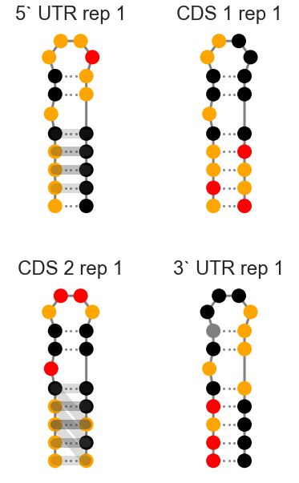

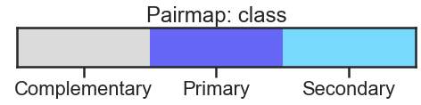

```python
plot = rnav.plot_ss(
    samples[2:],
    ss=MS2_stemloop,
    interactions="pairmap",
    interactions_filter={"all_pairs": True},
    profile="dmsmap",
    colors="profile",
    plot_kwargs={"data_lw": 12}
)
for i in range(len(samples[2:])):
    plot.get_ax(i).margins(x=1, y=0.1)
plot.set_figure_size()

plot.save('./images/all_TH_ss.svg')
```

## Plot for comparing reactivities between target mRNA biological replicates through a linear regression of nucleotide reactivities

Target mRNA biological replicates being compared are labeled on top of individual plots

### Loading Data

```python
UTR3_2 = rnav.Sample(
    sample="3` UTR rep 2",
    fasta=UTR3_seq,
    dmsmap="./3UTR_Rep2/3UTR_3UTR_profile.txt")
UTR3_TP_2 = rnav.Sample(
    sample='3` UTR with TP expressed rep 2',
    fasta=UTR3_seq,
    dmsmap='./3UTR-TP-amp3_Rep2/3UTR_primer3_3UTR_primer3_profile.txt')
UTR5_2 = rnav.Sample(
    sample="5` UTR rep 2",
    fasta=UTR5_seq,
    dmsmap="./5UTR_Rep2/5UTR_5UTR_profile.txt")
CDS1_2 = rnav.Sample(
    sample="CDS 1 rep 2",
    fasta=CDS1_seq,
    dmsmap="./CDS1_Rep2/CDS1_CDS1_profile.txt")
CDS1_TP_2 = rnav.Sample(
    sample='CDS1 with TP expressed rep 2',
    fasta=CDS1_seq,
    dmsmap='./CDS1-TP-amp1_Rep2/CDS1_primer1_CDS1_primer1_profile.txt')
CDS2_2 = rnav.Sample(
    sample="CDS 2 rep 2",
    fasta=CDS2_seq,
    dmsmap="./CDS3_Rep2/CDS3_CDS3_profile.txt")
```

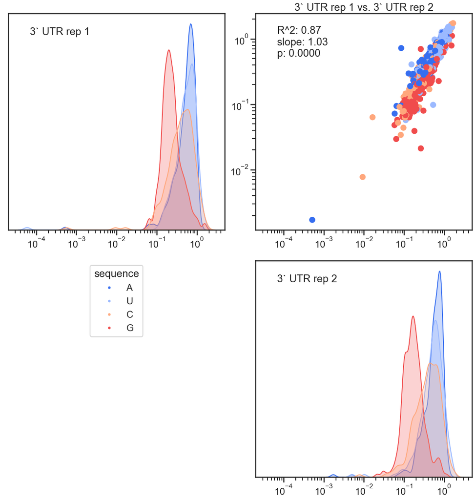

```python
plot = rnav.plot_linreg(
    samples=[UTR3, UTR3_2],
    seq_source=base_seq,
    column="Norm_profile",
    colorby="sequence",
    ct=None,
)

plot.save('./images/3UTR_LinearReg.svg')
```

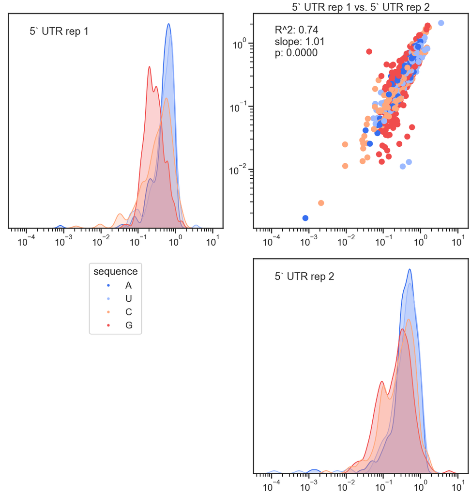

```python
plot = rnav.plot_linreg(
    samples=[UTR5, UTR5_2],
    seq_source=base_seq,
    column="Norm_profile",
    colorby="sequence",
    ct=None,
)

plot.save('./images/5UTR_LinearReg.svg')
```

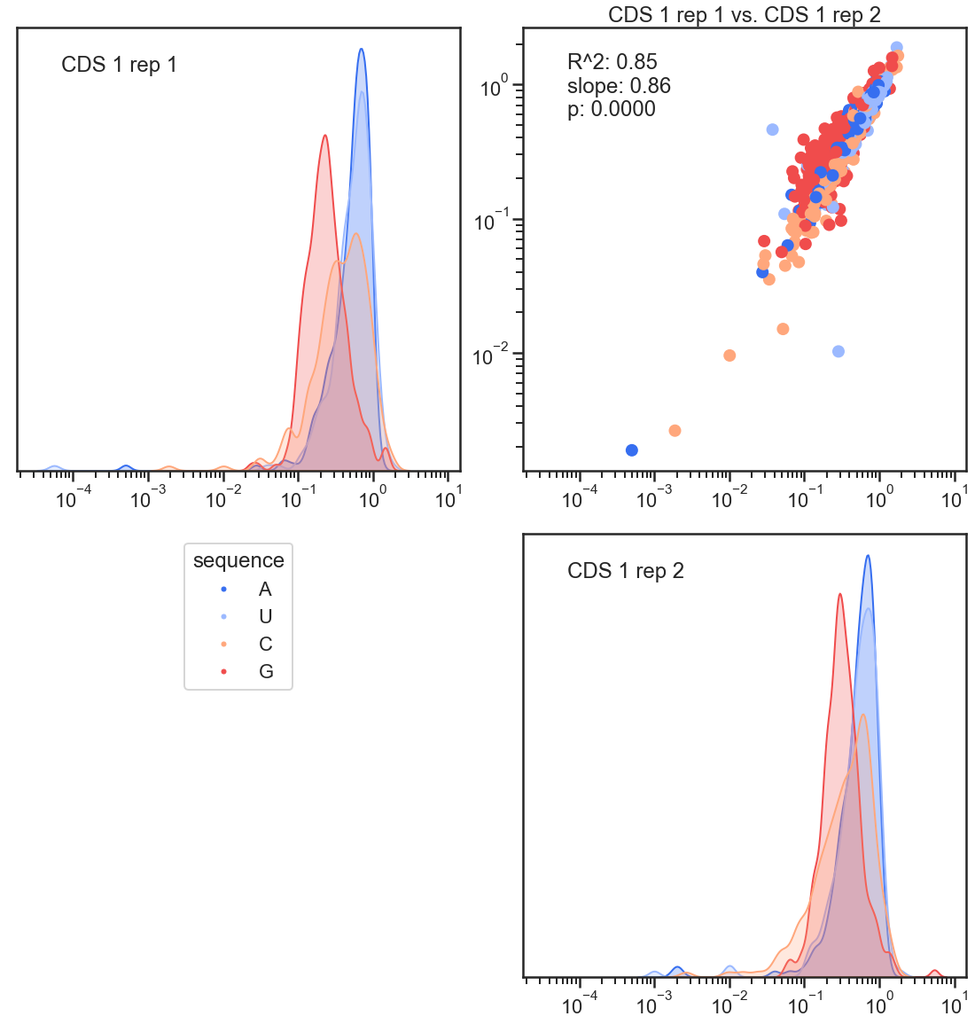

```python
plot = rnav.plot_linreg(
    samples=[CDS1, CDS1_2],
    seq_source=base_seq,
    column="Norm_profile",
    colorby="sequence",
    ct=None,
)

plot.save('./images/CDS1_LinearReg.svg')
```

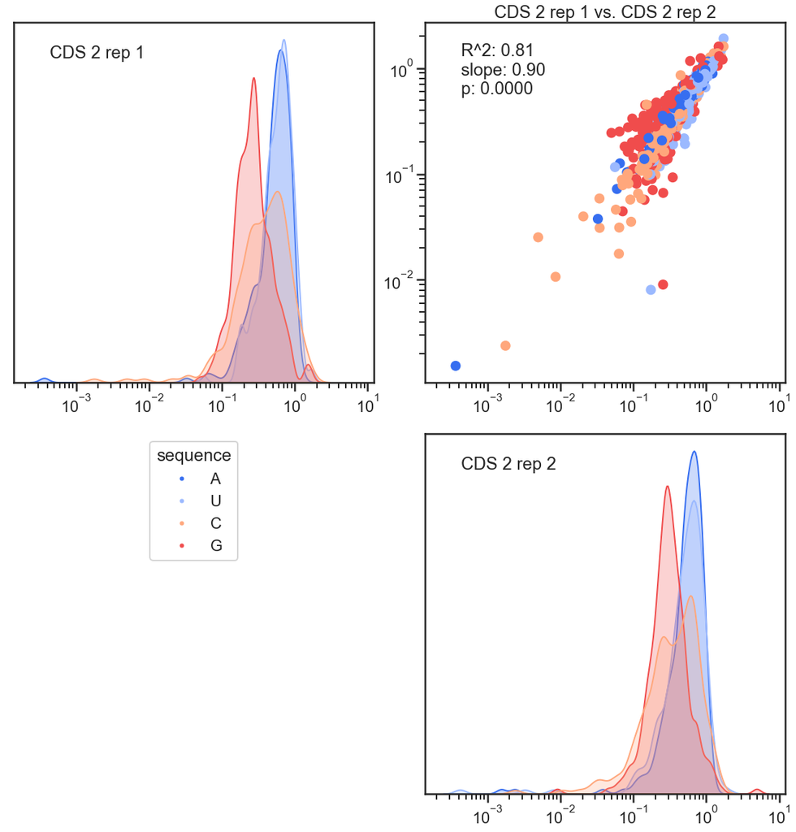

```python
plot = rnav.plot_linreg(
    samples=[CDS2, CDS2_2],
    seq_source=base_seq,
    column="Norm_profile",
    colorby="sequence",
    ct=None,
)

plot.save('./images/CDS2_LinearReg.svg')
```

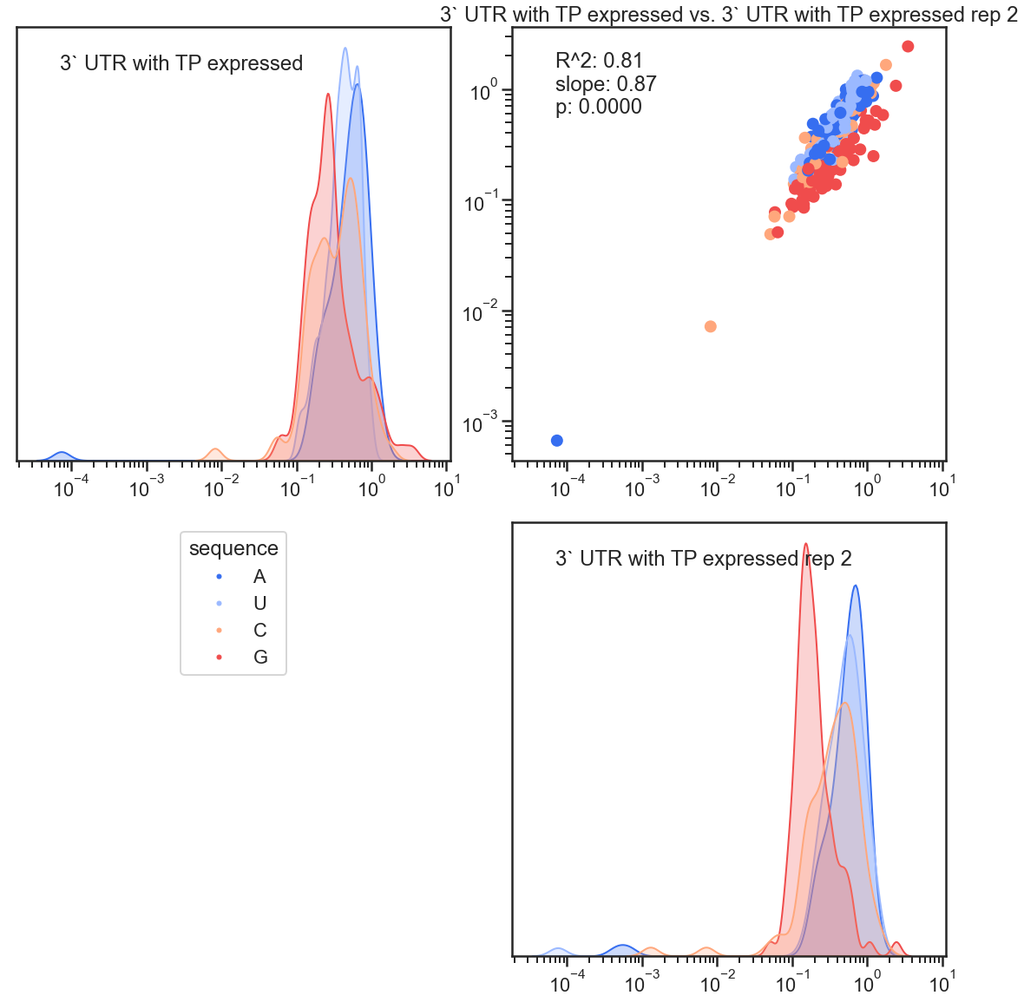

```python
plot = rnav.plot_linreg(
    samples=[UTR3_TP, UTR3_TP_2],
    seq_source=base_seq,
    column="Norm_profile",
    colorby="sequence",
    ct=None,
)

plot.save('./images/3UTR_TP_LinearReg.svg')
```

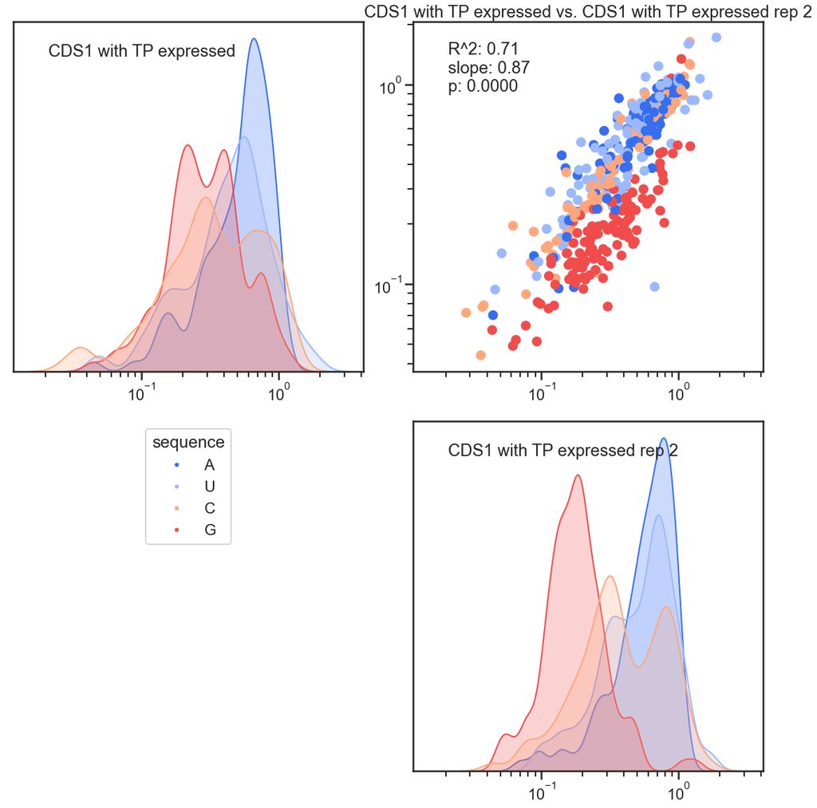

```python
plot = rnav.plot_linreg(
    samples=[CDS1_TP,  CDS1_TP_2],
    seq_source=base_seq,
    column="Norm_profile",
    colorby="sequence",
    ct=None,
)

plot.save('./images/CDS1_TP_LinearReg.svg')
```